# Aside

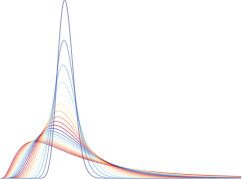

## Contact

- nick.strayer@gmail.com
- NicholasStrayer
- github.com/nstrayer
- [nickstrayer.me](http://nickstrayer.me/)
- (734) 645-0110

## Language Skills

R

Javascript (d3.js)

Python

Bash

SQL

C++

AWK

## Open Source Contributions

All projects available at `github.com/nstrayer/<name>`

- `shinysense`: R package to use sensor data in Shiny apps
- `tuftesque`: Hugo theme (behind LiveFreeOrDichotomize.com)
- `slid3r`: D3 add-on for fully svg slider inputs

## More info

See full CV at nickstrayer.me/cv for more complete list of positions and publications.

## Disclaimer

Made w/ [**pagedown**](https://github.com/rstudio/pagedown).

Source code: github.com/nstrayer/cv.

Last updated on 2026-09-26.

# Main

## Nick Strayer

I have made [visualizations viewed by hundreds of thousands of people](https://www.nytimes.com/interactive/2016/08/26/us/college-student-migration.html), [sped up query times for 25 terabytes of data by an average of 4,800 times](https://livefreeordichotomize.com/2019/06/04/using_awk_and_r_to_parse_25tb/), and built [packages for R](https://github.com/nstrayer/shinysense) that let you [do magic](http://nickstrayer.me/dataDayTexas/).

Currently searching for a data science position that allows me to build tools using visualization and machine learning to help people explore and understand their data.

## Education

### PhD. Student, Criminology/Criminal Justice

Phoenix, AZ

Arizona State University

- A third year doctoral student with a research interest in intelligence-led policing

### M.S., Criminology/Criminal Justice

California State University- Long Beach

2024 - 2022

- Thesis: The Effect of Intelligence on Illicit Fentanyl Distribution Networks in Long Beach City (Chair: Aili Malm, Ph.D.)

### B.S., Criminal Justice, Pscychology

Burlington, VT

University of Vermont

2015 - 2011

## Selected Positions

### Graduate Research Assistant

Vanderbilt University

TBILab (Yaomin Xu’s Lab)

2020 - 2015

- Primarily working with large EHR and Biobank datasets.
- Developing network-based methods to investigate and visualize clinically relevant patterns in data.

### Data Science Researcher

Johns Hopkins University

Data Science Lab

2018 - 2017

- Building R Shiny applications in the contexts of wearables and statistics education.
- Work primarily done in R Shiny and Javascript (node and d3js).

### Data Journalist - Graphics Department

New York, New York

New York Times

2016

- Reporter with the graphics desk covering topics in science, politics, and sport.
- Work primarily done in R, Javascript, and Adobe Illustrator.

## Selected Writing

### [Using AWK and R to Parse 25tb](https://livefreeordichotomize.com/2019/06/04/using_awk_and_r_to_parse_25tb/)

N/A

LiveFreeOrDichotomize.com

2019

- Story of parsing large amounts of genomics data.
- Provided advice for dealing with data much larger than disk.
- Reached top of HackerNews.

### [The Traveling Metallurgist](https://livefreeordichotomize.com/2017/09/25/the-traveling-metallurgist/)

N/A

LiveFreeOrDichotomize.com

2017

- Pure javascript implementation of traveling salesman solution using simulated annealing.
- Allows reader to customize the number and location of cities to attempt to trick the algorithm.

### [The Great Student Migration](https://www.nytimes.com/interactive/2016/08/26/us/college-student-migration.html?smid=pl-share)

N/A

The New York Times

2016

- Most shared and discussed article from the New York Times for August 2016.